# Project 1 Draft Report

Author

Siddharth Venkiteswaran

## Plastic Pollution

The plastic pollution data set contains information from the organization, Break Free From Plastic, and their audits on plastic pollution and the efforts to clean it up within different countries. It contains data from audits in 2019 and 2020, in addition to the parent company from where the pollution originated from. The plastic is specifically classified by recycling codes.

Looking at the cleaning that has been done to the data so far, it is clear that from the cleaning script, the columns have been set to have values of either values of characters or doubles. This applies for both 2019 and 2020. Furthermore, for 2019, there has been an str_replace operation conducted to better set the names from the file which it was collected from. Additionally, there has been a mutate operation conducted to create new variables of pp and ps, with if else statements to handle NA values within the variable pp_2.

### Initial Research Questions

1. Which companies had the highest grand total number of plastics thrown out in 2019 and 2020?
2. Which countries had clean up efforts that found the largest grand total of plastics in 2019 and 2020?
3. Does the amount of plastic waste within countries that are part of the Paris Climate Agreement significantly differ from countries who are not a part of the agreement?
4. Do countries with a higher GDP tend to contribute to rising levels of plastic waste?

```r
library(tidyverse)
```

```r
plastics <- readr::read_csv('https://raw.githubusercontent.com/rfordatascience/tidytuesday/main/data/2021/2021-01-26/plastics.csv')
```

### Visualization Sketches

https://excalidraw.com/#json=buS3O8kzDji6O6ABK-REi,E2ouf_AO14QoCr69V5YTWw

## Data Summaries Using Existing Columns

### Data Summary 1

**Question**: Which parent companies contribute the most total plastic waste across all countries, and what share of the total recorded waste does each company account for?

```r
overall_total <- sum(plastics$grand_total, na.rm = TRUE)

company_share <- function(x, overall_total) {
  sum(x, na.rm = TRUE) / overall_total
}

company_summary <- plastics |>
  filter(!is.na(parent_company),
         parent_company != "Grand Total",
         parent_company != "null",
         parent_company != "NULL",
         parent_company != "Unbranded") |>
  group_by(parent_company) |>
  summarize(
    total_plastic_waste = sum(grand_total, na.rm = TRUE),
    share_of_total = company_share(grand_total, overall_total),
    .groups = "drop"
  ) |>
  arrange(desc(total_plastic_waste)) |>
  slice_head(n = 10)

company_summary
```

```
# A tibble: 10 × 3
   parent_company               total_plastic_waste share_of_total
   <chr>                                      <dbl>          <dbl>
 1 The Coca-Cola Company                      25530        0.0212
 2 La Doo                                     15221        0.0126
 3 Universal Robina Corporation                8651        0.00718
 4 Nestle                                      8642        0.00717
 5 Unilever                                    8589        0.00713
 6 Colgate-Palmolive                           6545        0.00543
 7 Barna                                       6225        0.00517
 8 Assorted                                    6101        0.00506
 9 Pure Water, Inc.                            5347        0.00444
10 Pepsico                                     5155        0.00428
```

### Data Summary 2

**Question**: Which countries had clean up efforts that found the largest grand total of plastics in 2019 and 2020?

```r
## Uses iteration and a custom function
total_plastics <- function(input_country){

  grand_total_plastics <- plastics |>
    filter(country == input_country) |>
    distinct(year, grand_total) |>
    pull(grand_total)

  sum(grand_total_plastics, na.rm = TRUE)
}

plastics |>
  distinct(country) |>
  filter(country != "EMPTY") |>
  mutate(
    plastic_total = map_int(country, total_plastics)
    ) |>
  slice_max(plastic_total, n = 10)
```

```
# A tibble: 10 × 2
   country                         plastic_total
   <chr>                                   <int>
 1 Taiwan_ Republic of China (ROC)        241292
 2 NIGERIA                                157133
 3 Philippines                            125667
 4 Switzerland                             66588
 5 Nigeria                                 61123
 6 Indonesia                               34173
 7 Vietnam                                 28347
 8 Kenya                                   27426
 9 ECUADOR                                 25346
10 United States of America                21158
```

## Data Summaries That Modify Columns

### Data Summary 3

**Question**: Which countries have the highest average amount of plastic collected per cleanup event?

```r
plastic_per_event <- function(input_country) {
  plastics |>
    filter(country == input_country) |>
    distinct(year, grand_total, num_events) |>
    summarise(
      total_plastic = sum(grand_total, na.rm = TRUE),
      total_events = sum(num_events, na.rm = TRUE)
    ) |>
    mutate(plastic_per_event = total_plastic / total_events) |>
    pull(plastic_per_event)
}

plastic_event_summary <- plastics |>
  distinct(country) |>
  mutate(plastic_per_event = map_dbl(country, plastic_per_event)) |>
  slice_max(plastic_per_event, n = 10)

plastic_event_summary
```

```
# A tibble: 10 × 2
   country                         plastic_per_event
   <chr>                                       <dbl>
 1 Taiwan_ Republic of China (ROC)            30162.
 2 Togo                                        2399.
 3 Bhutan                                      1750
 4 Benin                                       1066
 5 ECUADOR                                      818.
 6 Burkina Faso                                 535.
 7 Montenegro                                   356.
 8 Germany                                      304.
 9 Portugal                                     259.
10 Latvia                                       210.
```

### Data Summary 4

**Question**: Which nations had the highest average participation for cleanup events in 2019 and 2020?

```r
cleanup_totals <- function(input_country) {
  plastics |>
    filter(country == input_country) |>
    distinct(num_events, volunteers) |>
    mutate(total_vol = sum(volunteers, na.rm = T),
         total_events = sum(num_events, na.rm = T)) |>
    distinct(total_vol, total_events) |>
    mutate(vol_per_event = total_vol / total_events) |>
    pull(vol_per_event)
}

plastics |>
  distinct(country) |>
  mutate(
    avg_participation = map_dbl(country, cleanup_totals),
    rounded_participation = round(avg_participation)
  ) |>
  slice_max(avg_participation, n = 20)
```

```
# A tibble: 20 × 3
   country                         avg_participation rounded_participation
   <chr>                                       <dbl>                 <dbl>
 1 Taiwan_ Republic of China (ROC)           15659                   15659
 2 Bhutan                                     5300                    5300
 3 Cote D_ivoire                              1500                    1500
 4 Benin                                       929.                    929
 5 Colombia                                    502.                    502
 6 Montenegro                                  490.                    490
 7 ECUADOR                                     455                     455
 8 Ghana                                       282                     282
 9 Netherlands                                 277.                    277
10 Kenya                                       271                     271
11 Burkina Faso                                199                     199
12 South Africa                                177                     177
13 Philippines                                 126.                    126
14 NIGERIA                                     118.                    118
15 Nigeria                                     117.                    117
16 Bangladesh                                  114.                    114
17 Togo                                         92                      92
18 Indonesia                                    88.3                    88
19 Tanzania                                     78.4                    78
20 Turkey                                       78                      78
```

## Project Checkpoint #3

```r
library(glue)
library(httr)
library(tidyjson)
library(jsonlite)
library(readr)
library(tidyverse)
library(ggalluvial)
library(ggrepel)
```

**Create a function to pull data from the API**

```r
get_gdp <- function(country_code, key = my_key) {
  url <- glue("https://api.api-ninjas.com/v1/gdp?country={country_code};X-Api-Key={key}")

  my_data <- safely(fromJSON)(url)

  if (is.null(my_data$result)) {
    return(NA)
  } else {
    return(my_data$result |> filter(year %in% c(2019, 2020)))
  }
}
```

```r
## Create a list of the top 10 countries with the highest total plastics
library(countrycode)

top_plastic_countries <- plastics |>
  distinct(country) |>
  filter(!country %in% c("EMPTY", "Taiwan_ Republic of China (ROC)")) |>  ## Dropping Taiwan because of its contested status in the world (some supplemental data does not include Taiwan)
  mutate(
    plastic_total = map_int(country, total_plastics),
    country_code = countrycode(country, origin = "country.name", destination = "iso3c")
  ) |>
  filter(!is.na(country_code)) |> ## Dropping Nigeria's duplicate
  filter(plastic_total != 61123) |> ## Added security for removing the specific duplicate
  slice_max(plastic_total, n = 50) |>
  pull(country_code)
```

**Pull data from the API**

```r
Sys.sleep(20)
## Create a list of the countries with their GDP
gdp_list <- top_plastic_countries |>
  map(get_gdp)

## Double check for NAs
gdp_list |>
  is.na() |>
  sum()
```

**Turn the data into a CSV file**

```r
## Turn this into a tibble to join with our original data frame
gdp_data <- gdp_list |>
  keep(is.data.frame) |>
  bind_rows() |>
  rename(country_code = country)

gdp_data |>
  pull(country_code)

## Saving the csv locally
write.csv(gdp_data, "gdp.csv", row.names = FALSE)
```

```r
## Rereading in the data from the local file
gdp_df <- read.csv("gdp.csv")
```

**Join the data sets together**

```r
plastics_top <- plastics |>
  filter(!country %in% c("EMPTY",
                         "Nigeria",
                         "Taiwan_ Republic of China (ROC)",
                         "United Kingdom")) |>
  mutate(
    country_code = countrycode(country, origin = "country.name", destination = "iso3c")
  ) |>
  filter(country_code %in% top_plastic_countries) |>
  left_join(gdp_df)

head(plastics_top)
```

```
# A tibble: 6 × 21
  country    year parent_company empty  hdpe  ldpe     o   pet    pp    ps   pvc
  <chr>     <dbl> <chr>          <dbl> <dbl> <dbl> <dbl> <dbl> <dbl> <dbl> <dbl>
1 Argentina  2019 Grand Total        0   215    55   607  1376   281   116    18
2 Argentina  2019 Unbranded          0   155    50   532   848   122   114    17
3 Argentina  2019 The Coca-Cola…     0     0     0     0   222    35     0     0
4 Argentina  2019 Secco              0     0     0     0    39     4     0     0
5 Argentina  2019 Doble Cola         0     0     0     0    38     0     0     0
6 Argentina  2019 Pritty             0     0     0     0    22     7     0     0
# ℹ 10 more variables: grand_total <dbl>, num_events <dbl>, volunteers <dbl>,
#   country_code <chr>, gdp_nominal <dbl>, gdp_per_capita_nominal <dbl>,
#   gdp_ppp <dbl>, gdp_per_capita_ppp <dbl>, gdp_ppp_share <dbl>,
#   gdp_growth <dbl>
```

```r
renewable_data <- read.csv("renewable-energy.csv")
## Data found from https://github.com/datasets/world-development-indicators/tree/main/indicators/eg.fec.rnew.zs

plastics_top <- plastics_top |>
  left_join(renewable_data |>
              filter(Year %in% c(2019, 2020),
                     Country.Code %in% plastics_top$country_code),
            by = c("country_code" = "Country.Code",
                   "year" = "Year")) |>
  select(-Country.Name)
```

### New Data Descriptions

**GDP Data Description**

The GDP data set has been extracted from the API Ninjas “GDP” API. In this case, the data has been programatically obtained in R by making an API call for each country by its ISO3 country code. Annual Gross Domestic Product (GDP) in U.S. Dollars has been recorded in this data set.

However, for this assignment, the years included have been limited to 2019 and 2020. Therefore, each country will appear twice in this data set corresponding to the two years. The data is in the form of a Tidy Data Frame, and it would later be merged with the plastic data set.

**Renewable Energy Data Description**

The renewable energy dataset was sourced from an open-source data set provided on GitHub and is based on World Development Indicators. The data set consists of country-specific information about renewable energy consumption over time.

In this case, the renewable energy data set has been filtered to include only the years 2019 and 2020 as well as only those countries that appear in the plastic data set. This filtering was done using ISO3 codes.

Key variables include:

- Country Code : ISO3 country code
- Year: year of observation
- renewable energy consumption, measured as the percentage of total final energy consumption from renewable sources

This dataset was merged with the GDP and plastics datasets to support comparative analysis across countries.

### Additional Data Summaries/Visualizations

```r
renewable_summary <- plastics_top |>
  filter(country_code %in% top_plastic_countries) |>
  distinct(country,
           country_code,
           year,
           grand_total,
           Value) |>
  group_by(country,
           country_code) |>
  summarize(
    total_waste = sum(grand_total, na.rm = TRUE),
    renewable_pct = mean(Value, na.rm = TRUE),
    .groups = "drop"
  ) |>
  filter(country != "Ecuador") |>
  arrange(desc(total_waste))

renewable_summary
```

```
# A tibble: 50 × 4
   country                  country_code total_waste renewable_pct
   <chr>                    <chr>              <dbl>         <dbl>
 1 NIGERIA                  NGA               157133          80.1
 2 Philippines              PHL               125667          27.9
 3 Switzerland              CHE                66588          25.7
 4 Indonesia                IDN                34173          20.7
 5 Vietnam                  VNM                28347          19.8
 6 Kenya                    KEN                27426          68.5
 7 ECUADOR                  ECU                25346          17.7
 8 United States of America USA                21158          10.8
 9 Burkina Faso             BFA                20348          72.8
10 India                    IND                19655          35.1
# ℹ 40 more rows
```

**New Plot:** Plastic Waste vs. Renewable Energy Percentage by Country

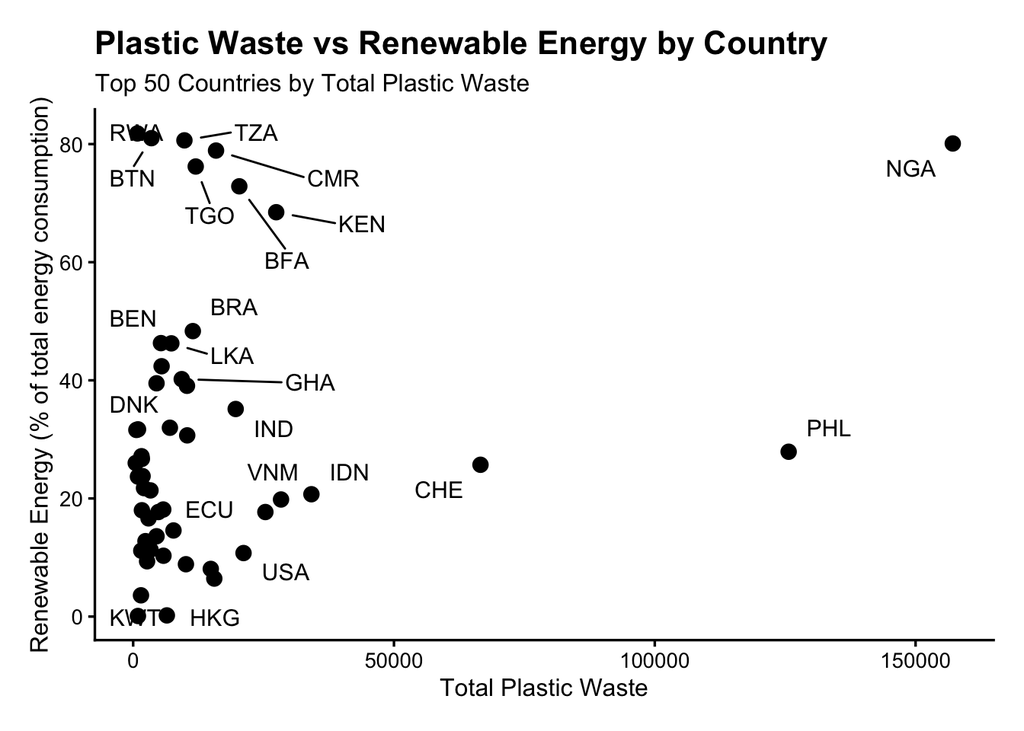

```r
ggplot(renewable_summary, aes(x = total_waste, y = renewable_pct)) +
  geom_point(size = 3, color = "black") +
  geom_text_repel(
    aes(label = country_code),
    size = 4,
    box.padding = 0.5,
    point.padding = 0.5
  ) +
  labs(
    title = "Plastic Waste vs Renewable Energy by Country",
    subtitle = "Top 50 Countries by Total Plastic Waste",
    x = "Total Plastic Waste",
    y = "Renewable Energy (% of total energy consumption)"
  ) +
  theme_classic(base_size = 13) +
  theme(
    plot.title = element_text(face = "bold", size = 16),
    plot.subtitle = element_text(size = 12),
    plot.margin = margin(15, 15, 15, 15),
    axis.title = element_text(size = 12)
  )
```

**New Plot:** GDP vs. Total Plastic Waste by Country

```r
library(ggalluvial)
library(paletteer)
```

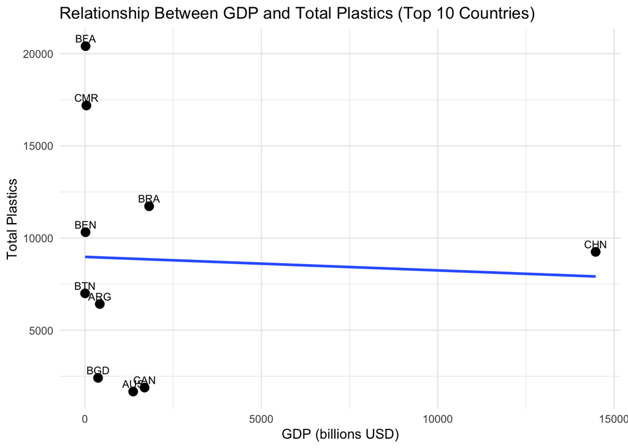

```r
top10_codes <- plastics_top |>
  distinct(country_code) |>
  slice_head(n = 10) |>
  pull(country_code)

country_plot <- plastics_top |>
  filter(country_code %in% top10_codes) |>
  group_by(country, country_code) |>
  summarize(
    total_plastic = sum(grand_total, na.rm = TRUE),
    gdp = mean(gdp_nominal, na.rm = TRUE),
    .groups = "drop"
  )

ggplot(country_plot, aes(x = gdp, y = total_plastic)) +
  geom_point(size = 3) +
  geom_smooth(method = "lm", se = FALSE) +
  geom_text(aes(label = country_code), vjust = -0.5, size = 3) +
  labs(
    title = "Relationship Between GDP and Total Plastics (Top 10 Countries)",
    x = "GDP (billions USD)",
    y = "Total Plastics"
  ) +
  theme_minimal()
```

## Project Checkpoint #4

**Improved Plot**

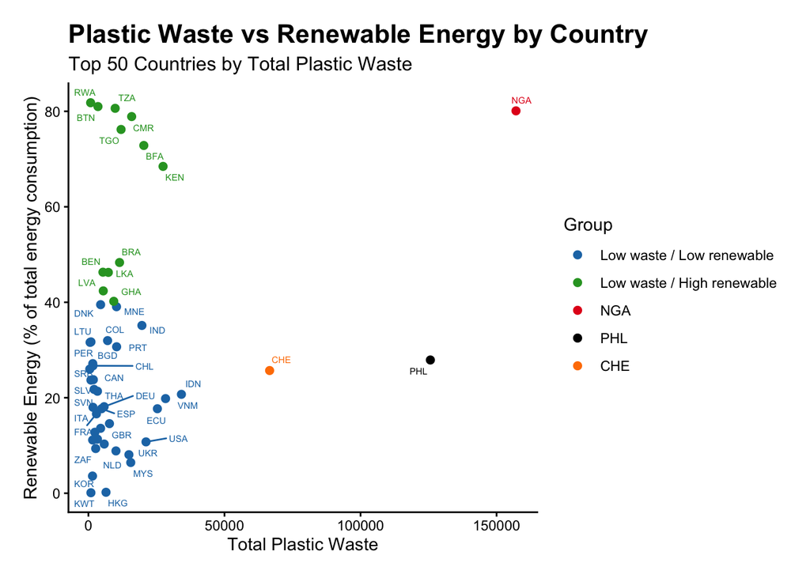

```r
renewable_summary <- renewable_summary |>
  mutate(
    group = case_when(
      country_code %in% c("NGA", "CHE", "PHL") ~ country_code,
      total_waste < 40000 & renewable_pct < 40 ~ "Low waste / Low renewable",
      total_waste < 40000 & renewable_pct >= 40 ~ "Low waste / High renewable",
      TRUE ~ "Other"
    ),
    group = factor(group,
      levels = c("Low waste / Low renewable",
                 "Low waste / High renewable",
                 "NGA",
                 "PHL",
                 "CHE")
    )
  )

ggplot(renewable_summary, aes(x = total_waste, y = renewable_pct, color = group)) +
  geom_point(size = 2) +
  geom_text_repel(
    aes(label = country_code),
    size = 2
  ) +
  labs(
    title = "Plastic Waste vs Renewable Energy by Country",
    subtitle = "Top 50 Countries by Total Plastic Waste",
    x = "Total Plastic Waste",
    y = "Renewable Energy (% of total energy consumption)",
    color = "Group"
  ) +
  scale_color_manual(values = c(
  "Low waste / Low renewable" = "#1f77b4",
  "Low waste / High renewable" = "#2ca02c",
  "Other" = "gray70",
  "NGA" = "#e41a1c",
  "CHE" = "#ff7f00",
  "PHL" = "#000000"
)) +
  theme_classic() +
  theme(
    plot.title = element_text(face = "bold", size = 16),
    plot.subtitle = element_text(size = 12),
    plot.margin = margin(15, 15, 15, 15))
```

**RQ:** Which countries have the highest amount of plastic waste, and what from what companies does that waste originate from?

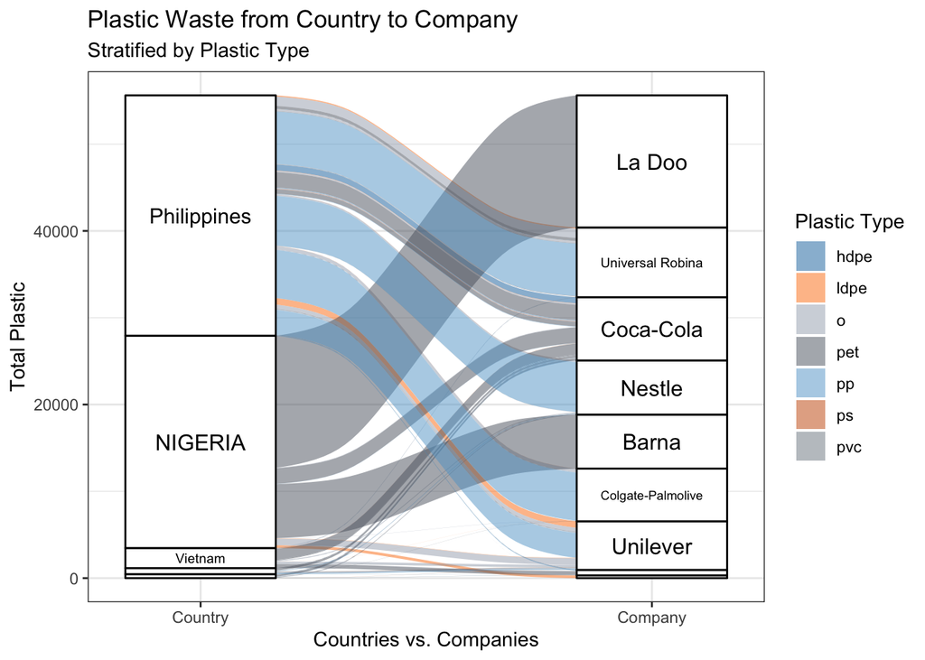

```r
## Get a list of the top 10 companies and the top 5 countries in plastic waste
top10_companies <- unique(company_summary$parent_company)
top5_codes <- top_plastic_countries[1:5]

## Convert the data into the long format
plastics_long <- plastics_top |>
  filter(parent_company %in% top10_companies,
         country_code %in% top5_codes) |>
  select(country, year, parent_company, hdpe, ldpe, o, pet, pp, ps, pvc) |>
  pivot_longer(
    cols = c(hdpe, ldpe, o, pet, pp, ps, pvc),
    names_to = "plastic_type",
    values_to = "total_plastic"
  ) |>
  filter(total_plastic > 0)

## Create the Sankey diagram
plastics_long |>
  mutate(
    country = fct_reorder(country,
                          total_plastic,
                          sum,
                          .desc = TRUE),
    parent_company = fct_reorder(parent_company,
                                 total_plastic,
                                 sum,
                                 .desc = TRUE),
    parent_company = recode(parent_company,
    "Universal Robina Corporation" = "Universal Robina",
    "The Coca-Cola Company" = "Coca-Cola")
  ) |>
  ggplot(aes(axis1 = country,
             axis2 = parent_company,
             y = total_plastic)) +
  scale_x_discrete(limits = c("Country", "Company"),
                   expand = c(.2, .05)) +
  geom_alluvium(aes(fill = plastic_type)) +
  geom_stratum() +
  ggfittext::geom_fit_text(stat = "stratum",
                           aes(label = after_stat(stratum)),
                           width = 1/4,
                           min.size = 3) +
  theme_bw() +
  scale_fill_paletteer_d("ggthemes::Color_Blind") +
  xlab("Countries vs. Companies") +
  ylab("Total Plastic") +
  ggtitle("Plastic Waste from Country to Company",
          "Stratified by Plastic Type") +
  labs(fill = "Plastic Type")
```

A simple linear regression model was used:

$Y_i$ = $\beta_0$ + $\beta_1 X_i$ + $\varepsilon_i$

$Y_i$ = renewable energy percentage for country $i$

$X_i$ = total plastic waste for country $i$

$\beta_0$ = intercept

$\beta_1$ = slope parameter

$\varepsilon_i\sim \text{iid } N(0, \sigma^2)$

```r
library(gt)
library(broom)
```

```r
## Used the broom package to better format our summary https://broom.tidymodels.org/
model <- lm(renewable_pct ~ total_waste, data = renewable_summary)

tidy(model) |>
  gt() |>
  tab_header(
    title    = "Linear Regression Results",
    subtitle = "Response: Renewable Energy Percentage | Predictor: Total Waste"
  ) |>
  tab_style(style = cell_text(weight = "bold"),
    locations = list(cells_column_labels(),
                     cells_title())) |>
  tab_caption("Table 1: Effect of Total Waste on Renewable Energy Percentage") |>
  cols_label(
    term      = "Term",
    estimate  = "Estimate",
    std.error = "Std. Error",
    statistic = "t-Statistic",
    p.value   = "p-Value"
  ) |>
  fmt_number(
    columns  = c(estimate, std.error, statistic),
    decimals = 4
  ) |>
  fmt_number(
    columns  = p.value,
    decimals = 4
  )
```

Table 1: Effect of Total Waste on Renewable Energy Percentage

Linear Regression Results

Response: Renewable Energy Percentage | Predictor: Total Waste

| Term | Estimate | Std. Error | t-Statistic | p-Value |
| --- | --- | --- | --- | --- |
| (Intercept) | 28.1728 | 3.6985 | 7.6174 | 0.0000 |
| total_waste | 0.0002 | 0.0001 | 1.7275 | 0.0905 |